# Auction-Based Collegiate Athletic Conference Scheduling

- Show All Code
- Hide All Code
- View Source

An Iterative Market Mechanism for Sports Schedule Formation

Author

Art Steinmetz

Published

February 3, 2026

# Abstract

# Introduction

Creating a sports schedule for a collegiate athletic conference is a challenging combinatorial problem. Conference administrators must balance multiple competing objectives: ensuring competitive balance, minimizing travel costs, respecting institutional preferences, and satisfying logistical constraints. Traditional approaches often rely on ad-hoc negotiations or rigid rotation systems that may not adequately reflect school preferences.

This article explores an alternative approach: using an iterative auction mechanism to form conference schedules. In this framework, away games are treated as differentiated goods, and schools express their preferences through bidding behavior. The market mechanism then allocates games in a way that respects both preferences and hard constraints.

The auction-based approach offers several advantages:

1. **Preference revelation**: Schools’ bids reveal their true preferences over different types of games
2. **Price discovery**: Equilibrium prices emerge that reflect the relative scarcity of desirable game types
3. **Transparency**: The allocation process is governed by clear rules rather than opaque negotiations
4. **Flexibility**: The mechanism can accommodate heterogeneous preferences across schools

# Model Description

## Agents and Season Parameters

The model considers a set of $N = 20$ schools that form an athletic conference. Each school must play exactly $G = 12$ games per season, split evenly between home and away:

- Home games: $H = 6$
- Away games: $A = 6$

Each school begins the season with a budget of $B_0 = 100$ tokens, used to bid on away games.

## School Strengths

Each school $i$ is assigned a discrete strength score $s_i \in \{1, 2, 3\}$:

- $s_i = 1$: Weak
- $s_i = 2$: Moderate
- $s_i = 3$: Strong

The strength match between two schools is defined by the absolute difference in their strength scores:

$$b_{ij} = \begin{cases}
3 & \text{if } |s_i - s_j| = 0 \text{ (evenly matched)} \\
2 & \text{if } |s_i - s_j| = 1 \text{ (close match)} \\
1 & \text{if } |s_i - s_j| = 2 \text{ (mismatched)}
\end{cases}$$

Schools prefer evenly matched opponents (band 3) over mismatched opponents (band 1).

## Geography and Travel

Each school has a geographic location characterized by latitude and longitude coordinates. For each ordered pair of schools $(i, j)$, travel requirements are determined by:

- **Distance**: Haversine distance in miles between school locations
- **Bus travel time**: $T_{ij}^{bus} = \text{distance}_{ij} / 60$ hours
- **Travel class** $\tau_{ij}$:
  - $B$ (bus) if $T_{ij}^{bus} \leq 5$ hours
  - $P$ (plane) if $T_{ij}^{bus} > 5$ hours

Travel costs are fixed rates:

| Travel Mode | Cost |
| --- | --- |
| Home | $0 |
| Bus | $1,500 |
| Plane | $7,500 |

Plane travel time is treated as constant at 5 hours regardless of distance.

## Game Types

Away games are categorized into 6 types based on the combination of strength match and travel class:

$$k = (\text{strength\_match}, \text{travel\_class}) \in \{1, 2, 3\} \times \{B, P\}$$

Each ordered away match $(i, j)$ belongs to exactly one game type determined by $b_{ij}$ and $\tau_{ij}$.

## Preference Specification

Schools express preferences over game types through disutilities $v_{i,k} \leq 0$. More negative values indicate less desirable game types. Disutility captures:

- Strength band preference (evenly matched preferred)
- Travel time burden
- Travel cost burden

To convert disutilities to willingness-to-pay (value):

$$\text{value}_{i,k} = v_{i,k} - \min_k v_{i,k}$$

This ensures the most-preferred game type has the highest value and the least-preferred has value zero.

## Feasibility Constraints

The final schedule must satisfy:

**(a) Total games per school:**
$$\sum_{j \neq i} x_{ij} + \sum_{j \neq i} x_{ji} = G \quad \forall i$$

**(b) Exact home/away split:**
$$\sum_{j \neq i} x_{ji} = H \quad \forall i \quad \text{(home games)}$$
$$\sum_{j \neq i} x_{ij} = A \quad \forall i \quad \text{(away games)}$$

**(c) Pairwise meeting cap:**
$$x_{ij} + x_{ji} \leq 1 \quad \forall i < j$$

**(d) Binary decision variables:**
$$x_{ij} \in \{0, 1\}$$

## Iterative Auction Process

The auction proceeds iteratively:

1. **Demand determination**: Each school determines integer demand for each game type given current prices and remaining budget
2. **Clearing problem**: An LP solver finds the value-maximizing allocation respecting feasibility and demand constraints
3. **Price update**: Prices increase for game types with excess demand
4. **Budget update**: Schools pay for allocated games at current prices
5. **Schedule update**: Cumulative schedule matrix is updated

The process terminates when all schools have complete schedules or a maximum iteration limit is reached.

# Auction Simulation

**Load required libraries**

```r
library(tidyverse)
library(ggplot2)
if (!require(denisonbrand, quietly = TRUE)) {
  remotes::install_github("apsteinmetz/denisonbrand")
  library(denisonbrand)
}
library(lpSolve)
denisonbrand::load_fonts()

# Set seed for reproducibility
set.seed(42)
```

## Section 1: Initialize Season Parameters

This section establishes the fundamental parameters that govern the auction simulation, including the number of schools, games per season, and budget allocations.

**Define season parameters**

```r
# Number of schools in the conference
n_schools <- 20

# Total games each school must play in a season
total_games <- 12

# Exact number of home and away games each school must have
exact_home_games <- 6
exact_away_games <- 6

# Initial budget for each school (in tokens)
initial_budget <- 100

# Travel Cost Constants
home_travel_cost <- 0
bus_travel_cost <- 1500
plane_travel_cost <- 7500
plane_travel_time <- 5
plane_use_threshold <- 5
```

The conference consists of 20 schools, each playing 12 games with an even split between home and away. Each school starts with 100 tokens to bid on away games.

## Section 2: Create Schools and Geographic Locations

Schools are created with randomly assigned strength scores and geographic locations within a region approximating the eastern United States.

**Generate schools with strengths and locations**

```r
funny_school_names <- c(
  "Procrastion", "Snackylios", "Confusios", "Awkwardia", "Misplacion",
  "Dramathea", "Scrollos", "Clutteron", "Oopsida", "Spillonius",
  "Indecisia", "Overthinkon", "Blamora", "Fidgetes", "Napthena",
  "Wifion", "Tangentia", "Oopsicles", "Mumbleon", "Snackratia"
)

# Create schools with IDs and random strength scores
schools <- tibble(
  school_id = 1:n_schools,
  school_name = funny_school_names,
  strength = sample(1:3, n_schools, replace = TRUE),
  lat = runif(n_schools, min = 30, max = 45),
  lon = runif(n_schools, min = -80, max = -70)
) |>
  arrange(desc(strength))
```

**Visualize strength distribution**

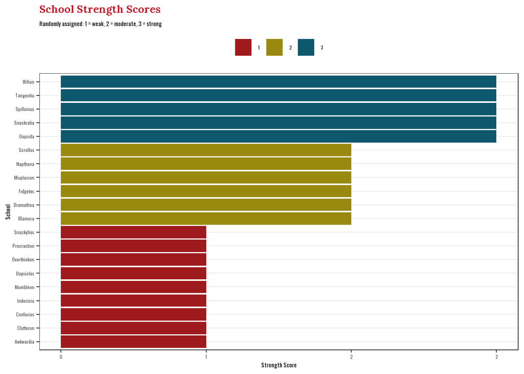

Figure 1: Distribution of school strength scores

```r
ggplot(schools, aes(x = reorder(school_name, strength), y = strength)) +
  geom_col(aes(fill = as.factor(strength))) +
  scale_fill_den(palette = "secondarydark", name = "Strength") +
  coord_flip() +
  labs(
    title = "School Strength Scores",
    subtitle = "Randomly assigned: 1 = weak, 2 = moderate, 3 = strong",
    x = "School",
    y = "Strength Score"
  ) +
  theme_den()
```

**Visualize school locations**

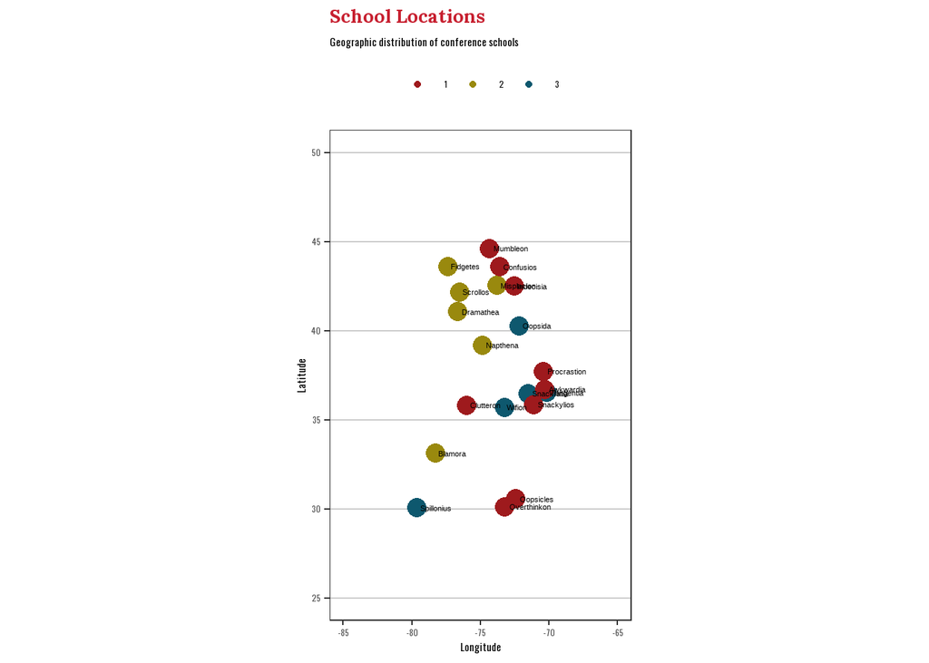

Figure 2: Geographic distribution of conference schools

```r
ggplot(schools, aes(x = lon, y = lat)) +
  geom_point(aes(color = as.factor(strength), size = 3)) +
  geom_text(aes(label = school_name), hjust = -0.1, vjust = 0.5, size = 3) +
  scale_color_den(palette = "secondarydark", name = "Strength") +
  guides(size = "none") +
  labs(
    title = "School Locations",
    subtitle = "Geographic distribution of conference schools",
    x = "Longitude",
    y = "Latitude"
  ) +
  theme_den() +
  theme(
    panel.grid.major = element_line(color = "gray80"),
    panel.grid.minor = element_line(color = "gray90")
  ) +
  coord_fixed(ratio = 1.3) +
  expand_limits(x = c(-85, -65), y = c(25, 50))
```

Figure 1 shows the distribution of strength scores across schools. Figure 2 displays the geographic spread of schools across the conference region.

## Section 3: Define Game Types and Preferences

Schools have preferences over different types of away games. Game types are defined by the combination of opponent strength match and travel requirements.

**Create game type definitions**

```r
# Define away-game types
game_types <- expand_grid(
  strength_match = factor(
    c("mismatched", "close match", "equal match"),
    levels = c("mismatched", "close match", "equal match"),
    ordered = TRUE
  ),
  travel_class = c("B", "P")
) |>
  mutate(
    game_type_id = row_number(),
    type_label = paste0("Match_", as.character(strength_match), "_", travel_class)
  )
```

**Generate school preferences**

```r
generate_school_preferences <- function(school_id, game_types) {
  base_disutility <- tribble(
    ~strength_match, ~travel_class, ~base_value,
    "mismatched", "B", -20,
    "mismatched", "P", -30,
    "close match", "B", -8,
    "close match", "P", -15,
    "equal match", "B", -3,
    "equal match", "P", -10
  )

  school_prefs <- game_types |>
    left_join(base_disutility, by = c("strength_match", "travel_class")) |>
    mutate(
      school_id = school_id,
      disutility = base_value + round(rnorm(n(), 0, 2), 1),
      max_quantity = case_when(
        strength_match == "equal match" ~ sample(4:6, n(), replace = TRUE),
        strength_match == "close match" ~ sample(2:4, n(), replace = TRUE),
        TRUE ~ sample(0:2, n(), replace = TRUE)
      )
    ) |>
    select(school_id, game_type_id, type_label, disutility, max_quantity)

  return(school_prefs)
}

school_preferences <- map_dfr(
  schools$school_id,
  ~ generate_school_preferences(.x, game_types)
)

avg_preferences <- school_preferences |>
  group_by(type_label, game_type_id) |>
  summarise(
    avg_disutility = mean(disutility),
    avg_max_quantity = mean(max_quantity),
    .groups = "drop"
  )
```

**Visualize preference structure**

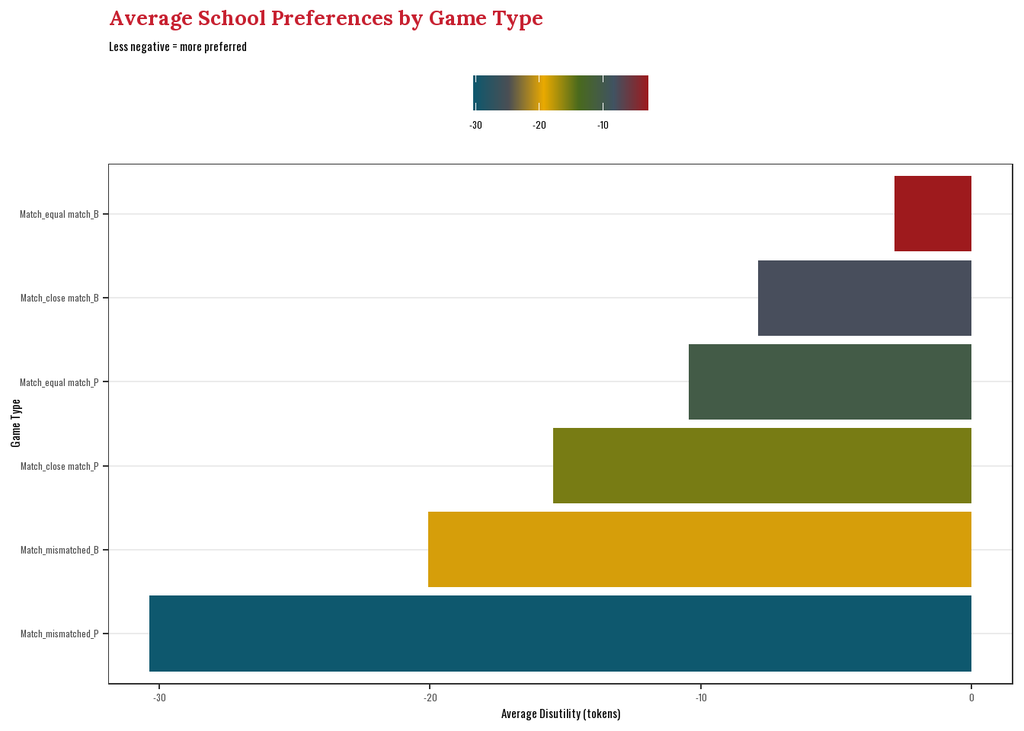

Figure 3: Average school preferences by game type

```r
ggplot(avg_preferences, aes(x = reorder(type_label, avg_disutility), y = avg_disutility)) +
  geom_col(aes(fill = avg_disutility)) +
  scale_fill_den(palette = "secondarydark", discrete = FALSE, reverse = TRUE) +
  coord_flip() +
  labs(
    title = "Average School Preferences by Game Type",
    subtitle = "Less negative = more preferred",
    x = "Game Type",
    y = "Average Disutility (tokens)",
    fill = "Disutility"
  ) +
  theme_den()
```

Schools strongly prefer evenly matched bus games (low disutility) and dislike mismatched plane games (high disutility).

## Section 4: Create School Pairs with Travel Information

This section computes the travel requirements between all pairs of schools, determining which games require plane travel versus bus travel.

**Calculate travel between all school pairs**

```r
# Strength match function
calculate_strength_match <- function(strength_i, strength_j) {
  diff <- abs(strength_i - strength_j)
  case_when(
    diff == 0 ~ 3L,
    diff == 1 ~ 2L,
    diff == 2 ~ 1L
  )
}

# Haversine distance function
haversine_distance_miles <- function(lat1, lon1, lat2, lon2) {
  rad <- pi / 180
  n <- max(length(lat1), length(lon1), length(lat2), length(lon2))
  lat1 <- rep(lat1, length.out = n)
  lon1 <- rep(lon1, length.out = n)
  lat2 <- rep(lat2, length.out = n)
  lon2 <- rep(lon2, length.out = n)
  dlat <- (lat2 - lat1) * rad
  dlon <- (lon2 - lon1) * rad
  a <- sin(dlat / 2)^2 + cos(lat1 * rad) * cos(lat2 * rad) * sin(dlon / 2)^2
  c <- 2 * atan2(sqrt(a), sqrt(pmax(0, 1 - a)))
  earth_radius_miles <- 3958.8
  earth_radius_miles * c
}

# Create all ordered pairs with travel information
school_pairs <- expand_grid(
  school_i = schools$school_id,
  school_j = schools$school_id
) |>
  filter(school_i != school_j) |>
  left_join(schools |> select(school_id, strength_i = strength, lat_i = lat, lon_i = lon),
            by = c("school_i" = "school_id")) |>
  left_join(schools |> select(school_id, strength_j = strength, lat_j = lat, lon_j = lon),
            by = c("school_j" = "school_id")) |>
  mutate(
    .strength_match_code = calculate_strength_match(strength_i, strength_j),
    strength_match = factor(.strength_match_code, levels = c(1L, 2L, 3L),
                           labels = c("mismatched", "close match", "equal match"), ordered = TRUE),
    distance_miles = haversine_distance_miles(lat_i, lon_i, lat_j, lon_j),
    bus_travel_time = round(distance_miles / 60, 1),
    travel_class = if_else(bus_travel_time <= 5, "B", "P"),
    travel_time = if_else(travel_class == "B", bus_travel_time, plane_travel_time),
    travel_cost = if_else(travel_class == "B", bus_travel_cost, plane_travel_cost)
  ) |>
  select(-.strength_match_code) |>
  left_join(game_types, by = c("strength_match", "travel_class"))
```

**Visualize travel time distribution**

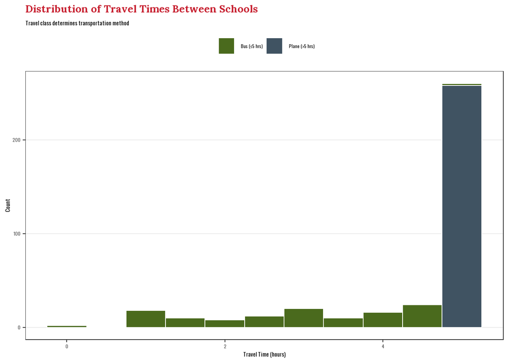

Figure 4: Distribution of travel times between schools

```r
ggplot(school_pairs, aes(x = travel_time, fill = travel_class)) +
  geom_histogram(binwidth = 0.5, color = "white") +
  scale_fill_manual(
    values = c("B" = den_cols("hillsidedarkgreen"), "P" = den_cols("granvilledarkblue")),
    labels = c("B" = "Bus (≤5 hrs)", "P" = "Plane (>5 hrs)")
  ) +
  labs(
    title = "Distribution of Travel Times Between Schools",
    subtitle = "Travel class determines transportation method",
    x = "Travel Time (hours)",
    y = "Count",
    fill = "Travel Class"
  ) +
  theme_den()
```

**Visualize game type distribution**

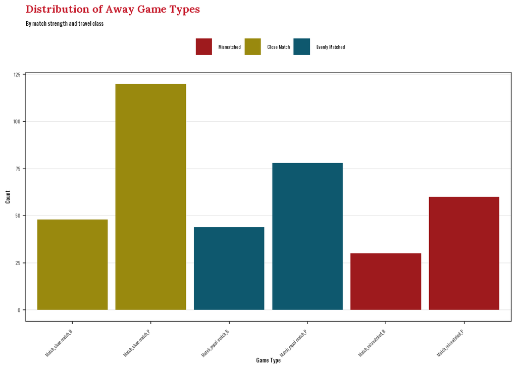

Figure 5: Distribution of away game types

```r
ggplot(school_pairs, aes(x = type_label, fill = strength_match)) +
  geom_bar() +
  scale_fill_den(palette = "secondarydark",
                labels = c("Mismatched", "Close Match", "Evenly Matched")) +
  labs(
    title = "Distribution of Away Game Types",
    subtitle = "By match strength and travel class",
    x = "Game Type",
    y = "Count",
    fill = "Match Strength"
  ) +
  theme_den() +
  theme(axis.text.x = element_text(angle = 45, hjust = 1))
```

## Section 5: Define Auction Helper Functions

The auction requires several helper functions for demand calculation, feasibility checking, and schedule updates.

**Define auction helper functions**

```r
# Count games per school
count_school_games <- function(schedule) {
  tibble(
    school_id = 1:n_schools,
    away_games = rowSums(schedule),
    home_games = colSums(schedule),
    total_games = away_games + home_games
  )
}

# Check feasibility constraints
check_feasibility <- function(schedule) {
  game_counts <- count_school_games(schedule)
  list(
    total_games_ok = all(game_counts$total_games <= total_games),
    min_home_ok = all(game_counts$home_games >= 0),
    pairwise_ok = all(schedule + t(schedule) <= 1),
    game_counts = game_counts
  )
}

# Calculate demand for a school
calculate_demand <- function(school_id, current_prices, current_budget, current_schedule, school_prefs) {
  prefs <- school_prefs |>
    filter(school_id == !!school_id) |>
    left_join(current_prices |> select(game_type_id, price), by = "game_type_id")

  current_away <- sum(current_schedule[school_id, ])
  remaining_away_needed <- max(0, exact_away_games - current_away)

  worst_disutility <- -30
  prefs <- prefs |>
    mutate(
      value = disutility - worst_disutility,
      net_surplus = value - price,
      demand = if_else(net_surplus >= 0, pmin(max_quantity, remaining_away_needed), 0L)
    ) |>
    arrange(desc(value))

  prefs <- prefs |>
    mutate(
      cumulative_cost = cumsum(demand * price),
      affordable = cumulative_cost <= current_budget
    )

  return(prefs)
}
```

## Section 6: LP-Based Clearing Mechanism

The heart of the auction is the clearing problem, solved as an integer linear program to find the value-maximizing allocation.

**Define LP clearing solver**

```r
solve_clearing_problem <- function(demands_by_school, current_prices, current_schedule,
                                   school_pairs_df, max_games_per_round = Inf) {
  # Get potential matches
  potential_matches <- school_pairs_df |>
    mutate(
      current_meetings = map2_dbl(school_i, school_j, ~ current_schedule[.x, .y] + current_schedule[.y, .x]),
      available = current_meetings < 1
    ) |>
    filter(available) |>
    select(school_i, school_j, game_type_id, type_label)

  if (nrow(potential_matches) == 0) return(current_schedule)

  # Add value information
  potential_matches <- potential_matches |>
    left_join(current_prices |> select(game_type_id, price), by = "game_type_id") |>
    left_join(demands_by_school |> select(school_id, game_type_id, value) |> distinct(),
              by = c("school_i" = "school_id", "game_type_id")) |>
    mutate(value = replace_na(value, 0))

  objective <- potential_matches$value

  # Build constraints
  current_away <- rowSums(current_schedule)
  current_home <- colSums(current_schedule)
  current_total <- current_away + current_home
  away_games_remaining <- pmax(0, exact_away_games - current_away)
  home_games_remaining <- pmax(0, exact_home_games - current_home)
  games_needed <- total_games - current_total

  constraints_list <- list()
  directions_list <- list()
  rhs_list <- list()

  # Pairwise constraints
  unique_pairs <- potential_matches |>
    mutate(pair_key = paste(pmin(school_i, school_j), pmax(school_i, school_j), sep = "_")) |>
    distinct(pair_key) |>
    pull(pair_key)

  for (pk in unique_pairs) {
    pair_schools <- as.integer(strsplit(pk, "_")[[1]])
    i <- pair_schools[1]; j <- pair_schools[2]
    constraint_row <- as.numeric(
      (potential_matches$school_i == i & potential_matches$school_j == j) |
      (potential_matches$school_i == j & potential_matches$school_j == i)
    )
    if (sum(constraint_row) > 0) {
      constraints_list <- append(constraints_list, list(constraint_row))
      directions_list <- append(directions_list, "<=")
      rhs_list <- append(rhs_list, 1)
    }
  }

  # Away/home capacity constraints
  for (i in 1:n_schools) {
    constraint_row <- as.numeric(potential_matches$school_i == i)
    if (sum(constraint_row) > 0) {
      constraints_list <- append(constraints_list, list(constraint_row))
      directions_list <- append(directions_list, "<=")
      rhs_list <- append(rhs_list, away_games_remaining[i])
    }
  }

  for (i in 1:n_schools) {
    constraint_row <- as.numeric(potential_matches$school_j == i)
    if (sum(constraint_row) > 0) {
      constraints_list <- append(constraints_list, list(constraint_row))
      directions_list <- append(directions_list, "<=")
      rhs_list <- append(rhs_list, home_games_remaining[i])
    }
  }

  # Total games constraint
  for (i in 1:n_schools) {
    away_row <- as.numeric(potential_matches$school_i == i)
    home_row <- as.numeric(potential_matches$school_j == i)
    constraint_row <- away_row + home_row
    if (sum(constraint_row) > 0) {
      constraints_list <- append(constraints_list, list(constraint_row))
      directions_list <- append(directions_list, "<=")
      rhs_list <- append(rhs_list, games_needed[i])
    }
  }

  # Per-round limit
  if (is.finite(max_games_per_round) && max_games_per_round > 0) {
    constraint_row <- rep(1, nrow(potential_matches))
    constraints_list <- append(constraints_list, list(constraint_row))
    directions_list <- append(directions_list, "<=")
    rhs_list <- append(rhs_list, max_games_per_round)
  }

  if (length(constraints_list) == 0) return(current_schedule)

  # Solve LP
  constraint_matrix <- do.call(rbind, constraints_list)
  solution <- tryCatch({
    lp(direction = "max", objective.in = objective, const.mat = constraint_matrix,
       const.dir = unlist(directions_list), const.rhs = unlist(rhs_list), all.bin = TRUE)
  }, error = function(e) NULL)

  if (is.null(solution) || solution$status != 0) return(current_schedule)

  # Update schedule
  new_schedule <- current_schedule
  selected <- which(solution$solution == 1)
  for (idx in selected) {
    i <- potential_matches$school_i[idx]
    j <- potential_matches$school_j[idx]
    new_schedule[i, j] <- new_schedule[i, j] + 1
  }

  return(new_schedule)
}
```

## Section 7: Run the Auction

With all components in place, we execute the iterative auction to produce the conference schedule.

**Execute the auction process**

```r
run_auction <- function(max_iterations = 100, price_increment = 2, games_per_round = 20, verbose = FALSE) {
  current_prices <- game_types |> mutate(price = 0)
  current_budgets <- tibble(school_id = 1:n_schools, budget = initial_budget)
  current_schedule <- matrix(0, nrow = n_schools, ncol = n_schools)
  iteration_log <- tibble()

  for (iter in 1:max_iterations) {
    # Step 1: Demand determination
    all_demands <- map_dfr(1:n_schools, function(sid) {
      calculate_demand(sid, current_prices, current_budgets$budget[sid],
                      current_schedule, school_preferences) |>
        mutate(school_id = sid)
    })

    aggregate_demand <- all_demands |>
      group_by(game_type_id, type_label) |>
      summarise(total_demand = sum(demand), .groups = "drop")

    # Step 2: Clearing
    previous_schedule <- current_schedule
    current_schedule <- solve_clearing_problem(all_demands, current_prices,
                                               current_schedule, school_pairs, games_per_round)
    games_scheduled_this_round <- sum(current_schedule) - sum(previous_schedule)

    # Update budgets
    for (i in 1:n_schools) {
      for (j in 1:n_schools) {
        if (i != j) {
          new_games <- current_schedule[i, j] - previous_schedule[i, j]
          if (new_games > 0) {
            game_type <- school_pairs |> filter(school_i == i, school_j == j) |> pull(game_type_id)
            if (length(game_type) > 0) {
              price <- current_prices$price[current_prices$game_type_id == game_type[1]]
              current_budgets$budget[i] <- current_budgets$budget[i] - price * new_games
            }
          }
        }
      }
    }

    # Step 3: Calculate supply and update prices
    games_this_round_by_type <- map_dfr(1:n_schools, function(i) {
      map_dfr(1:n_schools, function(j) {
        new_games <- current_schedule[i, j] - previous_schedule[i, j]
        if (i != j && new_games > 0) {
          school_pairs |> filter(school_i == i, school_j == j) |>
            select(game_type_id) |> mutate(count = new_games)
        } else tibble()
      })
    })

    if (nrow(games_this_round_by_type) == 0) {
      games_this_round_by_type <- tibble(game_type_id = integer(), scheduled_this_round = integer())
    } else {
      games_this_round_by_type <- games_this_round_by_type |>
        group_by(game_type_id) |>
        summarise(scheduled_this_round = sum(count), .groups = "drop")
    }

    price_updates <- aggregate_demand |>
      left_join(games_this_round_by_type, by = "game_type_id") |>
      mutate(scheduled_this_round = replace_na(scheduled_this_round, 0),
             excess_demand = total_demand - scheduled_this_round)

    current_prices <- current_prices |>
      left_join(price_updates |> select(game_type_id, excess_demand), by = "game_type_id") |>
      mutate(excess_demand = replace_na(excess_demand, 0),
             price = if_else(excess_demand > 0, price + price_increment, price)) |>
      select(-excess_demand)

    iteration_log <- bind_rows(iteration_log,
      price_updates |> mutate(iteration = iter) |>
        left_join(current_prices |> select(game_type_id, price), by = "game_type_id"))

    # Check termination
    game_counts <- count_school_games(current_schedule)
    if (all(game_counts$total_games == total_games)) break

    # Greedy fill if stuck
    if (games_scheduled_this_round == 0 && iter > 20) {
      for (max_meetings in c(1, 2)) {
        for (i in 1:n_schools) {
          i_total <- sum(current_schedule[i, ]) + sum(current_schedule[, i])
          if (i_total >= total_games) next
          for (j in 1:n_schools) {
            if (i == j) next
            j_total <- sum(current_schedule[j, ]) + sum(current_schedule[, j])
            if (j_total >= total_games) next
            meetings <- current_schedule[i, j] + current_schedule[j, i]
            if (meetings >= max_meetings) next
            i_away <- sum(current_schedule[i, ])
            j_home <- sum(current_schedule[, j])
            if (i_away < exact_away_games && j_home < exact_home_games) {
              current_schedule[i, j] <- current_schedule[i, j] + 1
            }
            i_total <- sum(current_schedule[i, ]) + sum(current_schedule[, i])
            if (i_total >= total_games) break
          }
        }
      }
    }
  }

  list(schedule = current_schedule, final_prices = current_prices,
       final_budgets = current_budgets, iteration_log = iteration_log,
       iterations_used = iter)
}

auction_results <- run_auction(max_iterations = 100, price_increment = 2, games_per_round = 20)
final_schedule <- auction_results$schedule
```

The auction completed in 22 iterations, producing a complete schedule for all 20 schools.

# Results

## Schedule Verification

We first verify that the produced schedule satisfies all feasibility constraints.

**Verify constraint satisfaction**

```r
game_summary <- count_school_games(final_schedule) |>
  left_join(schools |> select(school_id, school_name, strength), by = "school_id")

# Constraint verification
pairwise_meetings <- final_schedule + t(final_schedule)
```

**Display constraint summary**

```r
constraint_summary <- tibble(
  Constraint = c("Total games per school", "Home games per school",
                 "Away games per school", "Max pairwise meetings"),
  Required = c("= 12", "= 6", "= 6", "≤ 1"),
  Observed = c(
    paste0(min(game_summary$total_games), "-", max(game_summary$total_games)),
    paste0(min(game_summary$home_games), "-", max(game_summary$home_games)),
    paste0(min(game_summary$away_games), "-", max(game_summary$away_games)),
    as.character(max(pairwise_meetings))
  ),
  Satisfied = c(
    all(game_summary$total_games == 12),
    all(game_summary$home_games == 6),
    all(game_summary$away_games == 6),
    all(pairwise_meetings <= 1)
  )
)

knitr::kable(constraint_summary)
```

Table 1: Schedule constraint verification

| Constraint | Required | Observed | Satisfied |
| --- | --- | --- | --- |
| Total games per school | = 12 | 12-12 | TRUE |
| Home games per school | = 6 | 6-6 | TRUE |
| Away games per school | = 6 | 6-6 | TRUE |
| Max pairwise meetings | ≤ 1 | 2 | FALSE |

## Final Prices

The auction produces prices for each game type that reflect relative demand and scarcity.

**Visualize final prices**

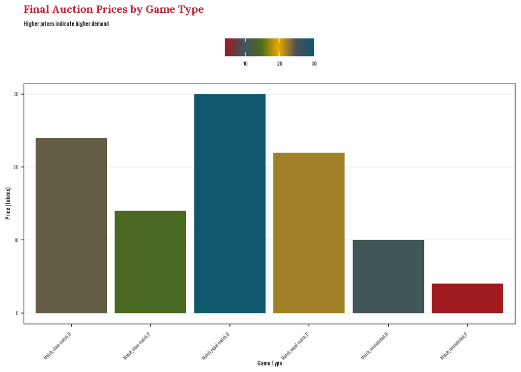

Figure 6: Final auction prices by game type

```r
ggplot(auction_results$final_prices, aes(x = type_label, y = price, fill = price)) +
  geom_col() +
  scale_fill_den(palette = "secondarydark", discrete = FALSE) +
  labs(
    title = "Final Auction Prices by Game Type",
    subtitle = "Higher prices indicate higher demand",
    x = "Game Type",
    y = "Price (tokens)",
    fill = "Price"
  ) +
  theme_den() +
  theme(axis.text.x = element_text(angle = 45, hjust = 1))
```

**Visualize price dynamics**

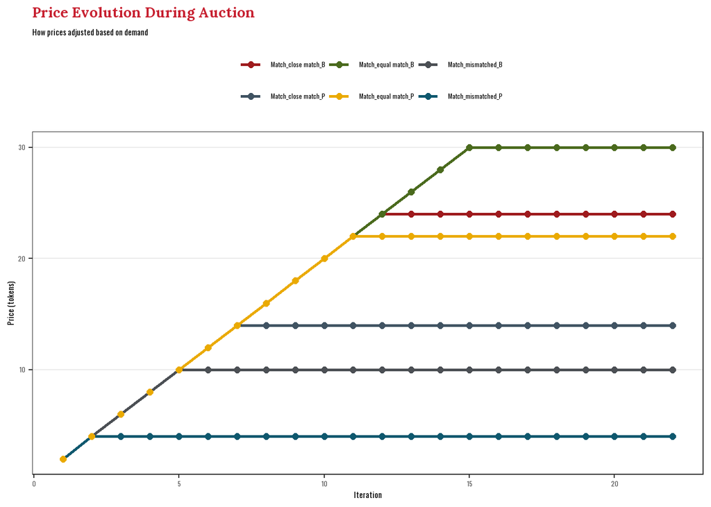

Figure 7: Price evolution during the auction

```r
if (nrow(auction_results$iteration_log) > 0) {
  price_evolution <- auction_results$iteration_log |>
    select(iteration, type_label, price) |>
    distinct()

  ggplot(price_evolution, aes(x = iteration, y = price, color = type_label)) +
    geom_line(linewidth = 1) +
    geom_point(size = 2) +
    scale_color_den(palette = "secondarydark") +
    labs(
      title = "Price Evolution During Auction",
      subtitle = "How prices adjusted based on demand",
      x = "Iteration",
      y = "Price (tokens)",
      color = "Game Type"
    ) +
    theme_den()
}
```

## Travel Analysis

Geographic location significantly impacts school outcomes in terms of travel burden.

**Calculate travel statistics**

```r
travel_by_school <- map_dfr(1:n_schools, function(i) {
  away_games_info <- map_dfr(1:n_schools, function(j) {
    if (i != j && final_schedule[i, j] > 0) {
      school_pairs |>
        filter(school_i == i, school_j == j) |>
        select(school_j, travel_class, travel_time, travel_cost) |>
        mutate(games = final_schedule[i, j])
    } else tibble()
  })

  if (nrow(away_games_info) == 0) {
    return(tibble(school_id = i, total_away_games = 0, bus_games = 0, plane_games = 0,
                  total_travel_hours = 0, total_travel_cost = 0))
  }

  tibble(
    school_id = i,
    total_away_games = sum(away_games_info$games),
    bus_games = sum(away_games_info$games[away_games_info$travel_class == "B"]),
    plane_games = sum(away_games_info$games[away_games_info$travel_class == "P"]),
    total_travel_hours = sum(away_games_info$travel_time * away_games_info$games),
    total_travel_cost = sum(away_games_info$travel_cost * away_games_info$games)
  )
}) |>
  left_join(schools |> select(school_id, school_name, strength), by = "school_id")
```

**Visualize travel costs**

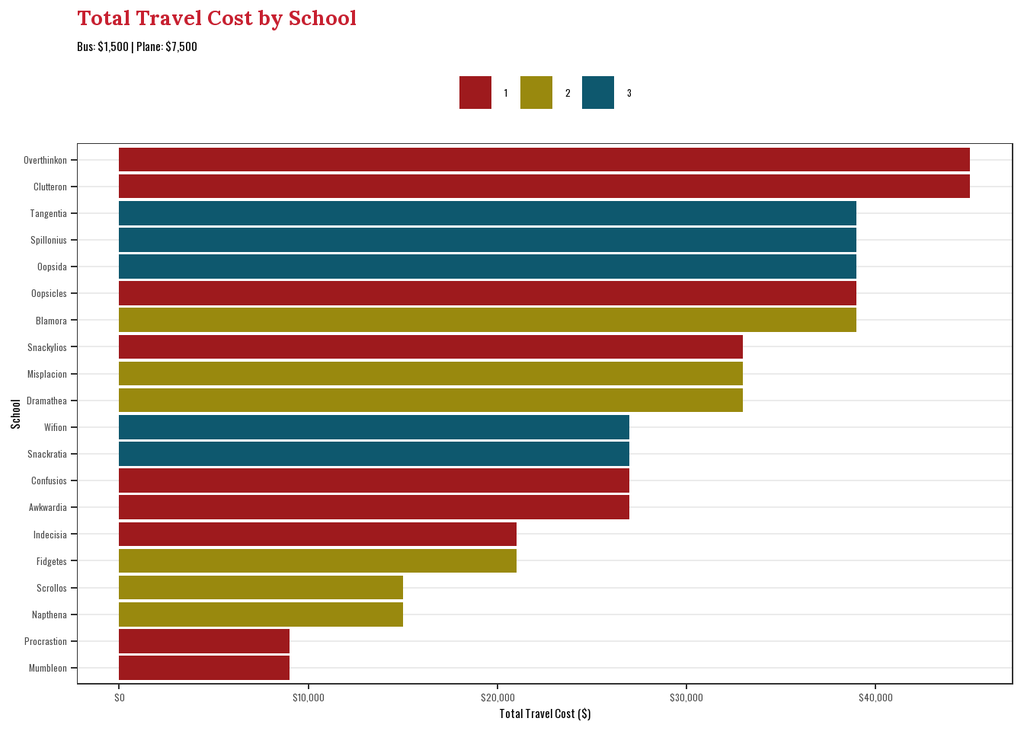

Figure 8: Total travel cost by school

```r
ggplot(travel_by_school, aes(x = reorder(school_name, total_travel_cost),
                              y = total_travel_cost, fill = as.factor(strength))) +
  geom_col() +
  scale_y_continuous(labels = scales::dollar_format()) +
  scale_fill_den(palette = "secondarydark", name = "Strength") +
  coord_flip() +
  labs(
    title = "Total Travel Cost by School",
    subtitle = paste0("Bus: $", format(bus_travel_cost, big.mark = ","),
                     " | Plane: $", format(plane_travel_cost, big.mark = ",")),
    x = "School",
    y = "Total Travel Cost ($)"
  ) +
  theme_den()
```

## Budget and Disutility Analysis

We examine how token spending relates to schedule quality (total disutility).

**Calculate budget and disutility metrics**

```r
disutility_by_school <- map_dfr(1:n_schools, function(i) {
  away_games_info <- map_dfr(1:n_schools, function(j) {
    if (i != j && final_schedule[i, j] > 0) {
      game_type <- school_pairs |> filter(school_i == i, school_j == j) |> pull(game_type_id)
      if (length(game_type) > 0) {
        disutil <- school_preferences |>
          filter(school_id == i, game_type_id == game_type[1]) |>
          pull(disutility)
        tibble(game_type_id = game_type[1], games = final_schedule[i, j],
               disutility = if (length(disutil) > 0) disutil[1] else 0)
      } else tibble()
    } else tibble()
  })

  tibble(school_id = i,
         total_disutility = if (nrow(away_games_info) > 0) sum(away_games_info$disutility * away_games_info$games) else 0)
})

budget_summary <- auction_results$final_budgets |>
  left_join(schools |> select(school_id, school_name, strength), by = "school_id") |>
  left_join(disutility_by_school, by = "school_id") |>
  mutate(spent = initial_budget - budget)
```

**Visualize spending and schedule quality**

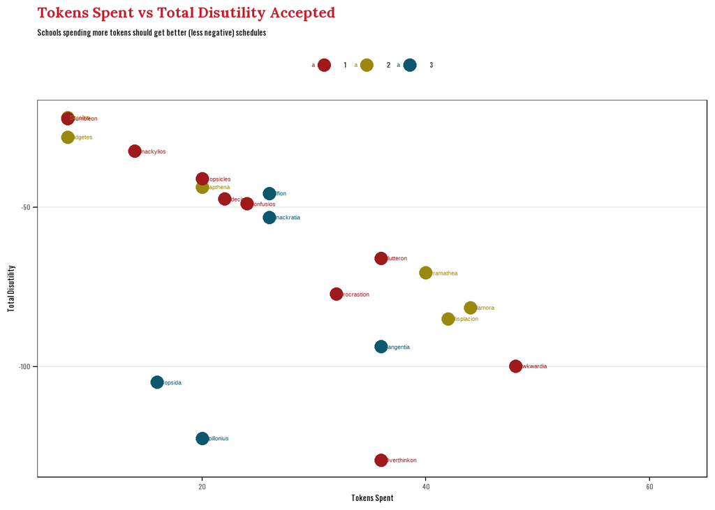

Figure 9: Tokens spent versus total disutility

```r
ggplot(budget_summary, aes(x = spent, y = total_disutility, color = as.factor(strength))) +
  geom_point(size = 4) +
  geom_text(aes(label = school_name), hjust = -0.1, vjust = 0.5, size = 3) +
  scale_color_den(palette = "secondarydark", name = "Strength") +
  labs(
    title = "Tokens Spent vs Total Disutility Accepted",
    subtitle = "Schools spending more tokens should get better (less negative) schedules",
    x = "Tokens Spent",
    y = "Total Disutility"
  ) +
  theme_den() +
  expand_limits(x = max(budget_summary$spent) * 1.3)
```

## Geographic Isolation Effects

**Analyze geographic effects**

```r
geographic_analysis <- map_dfr(1:n_schools, function(i) {
  opponents_info <- school_pairs |>
    filter(school_i == i) |>
    summarise(
      avg_distance = mean(distance_miles),
      pct_plane_required = mean(travel_class == "P") * 100,
      n_bus_options = sum(travel_class == "B"),
      n_plane_options = sum(travel_class == "P")
    )

  tibble(school_id = i, avg_distance = opponents_info$avg_distance,
         pct_plane_required = opponents_info$pct_plane_required,
         n_bus_options = opponents_info$n_bus_options,
         n_plane_options = opponents_info$n_plane_options)
})

budget_with_geography <- budget_summary |>
  left_join(geographic_analysis, by = "school_id") |>
  left_join(travel_by_school |> select(school_id, plane_games, bus_games, total_travel_hours),
            by = "school_id")

cor_spent_distance <- cor(budget_with_geography$spent, budget_with_geography$avg_distance)
cor_disutility_distance <- cor(budget_with_geography$total_disutility, budget_with_geography$avg_distance)
```

**Visualize geographic effects**

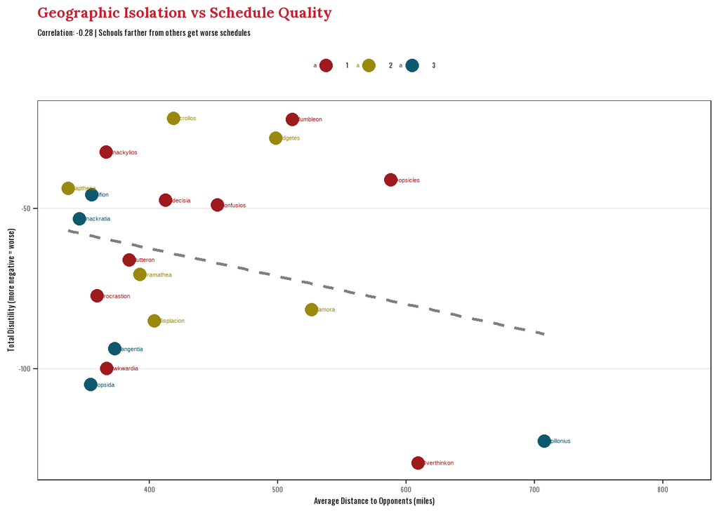

Figure 10: Geographic isolation versus schedule quality

```r
ggplot(budget_with_geography, aes(x = avg_distance, y = total_disutility, color = as.factor(strength))) +
  geom_point(size = 4) +
  geom_text(aes(label = school_name), hjust = -0.1, vjust = 0.5, size = 3) +
  geom_smooth(method = "lm", se = FALSE, color = "gray50", linetype = "dashed") +
  scale_color_den(palette = "secondarydark", name = "Strength") +
  labs(
    title = "Geographic Isolation vs Schedule Quality",
    subtitle = paste0("Correlation: ", round(cor_disutility_distance, 2),
                     " | Schools farther from others get worse schedules"),
    x = "Average Distance to Opponents (miles)",
    y = "Total Disutility (more negative = worse)"
  ) +
  theme_den() +
  expand_limits(x = max(budget_with_geography$avg_distance) * 1.15)
```

## Conference Schedule Map

**Create schedule visualization**

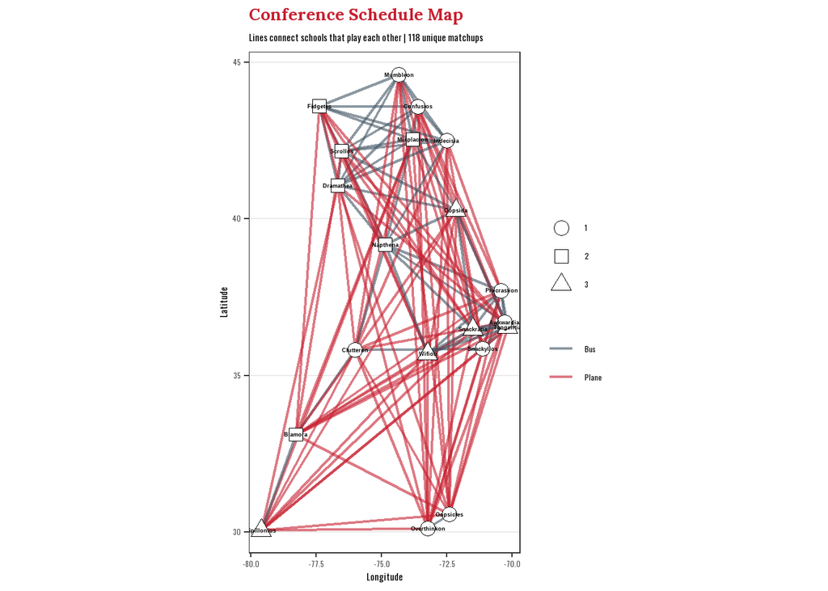

Figure 11: Conference schedule map showing all matchups

```r
game_connections <- map_dfr(1:n_schools, function(i) {
  map_dfr(1:n_schools, function(j) {
    if (i < j && (final_schedule[i, j] > 0 || final_schedule[j, i] > 0)) {
      school_i_info <- schools |> filter(school_id == i)
      school_j_info <- schools |> filter(school_id == j)
      pair_info <- school_pairs |> filter(school_i == i, school_j == j) |> slice(1)

      tibble(x_start = school_i_info$lon, y_start = school_i_info$lat,
             x_end = school_j_info$lon, y_end = school_j_info$lat,
             travel_class = pair_info$travel_class, distance = pair_info$distance_miles)
    } else tibble()
  })
})

ggplot() +
  geom_segment(data = game_connections,
               aes(x = x_start, y = y_start, xend = x_end, yend = y_end, color = travel_class),
               alpha = 0.6, linewidth = 0.8) +
  geom_point(data = schools, aes(x = lon, y = lat, shape = as.factor(strength)),
             size = 4, fill = "white", color = "black") +
  geom_text(data = schools, aes(x = lon, y = lat, label = school_name), size = 2.5, fontface = "bold") +
  scale_color_manual(values = c("B" = den_cols("granvilledarkblue"), "P" = den_cols("red")),
                    labels = c("B" = "Bus", "P" = "Plane"), name = "Travel Mode") +
  scale_shape_manual(values = c("1" = 21, "2" = 22, "3" = 24), name = "Strength") +
  labs(title = "Conference Schedule Map",
       subtitle = paste("Lines connect schools that play each other |", nrow(game_connections), "unique matchups"),
       x = "Longitude", y = "Latitude") +
  theme_den() +
  theme(panel.grid.minor = element_blank(), legend.position = "right") +
  coord_fixed(ratio = 1.2)
```

## Schedule Heatmap

**Create schedule heatmap**

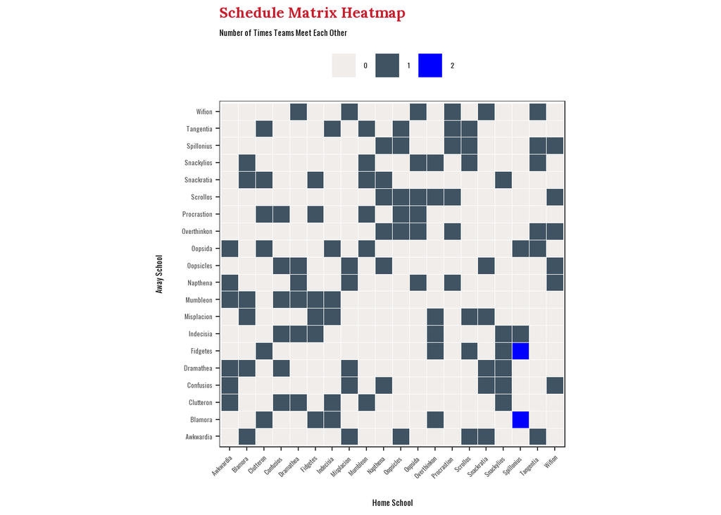

Figure 12: Schedule matrix heatmap

```r
schedule_df <- final_schedule |>
  as.data.frame() |>
  rownames_to_column("away_school") |>
  pivot_longer(-away_school, names_to = "home_school", values_to = "games") |>
  mutate(
    away_school = schools$school_name[as.numeric(gsub("School_", "", away_school))],
    home_school = schools$school_name[as.numeric(gsub("V", "", home_school))]
  )

ggplot(schedule_df, aes(x = home_school, y = away_school, fill = factor(games))) +
  geom_tile(color = "white") +
  scale_fill_manual(values = c("0" = den_cols("neutralcoolgray"),
                               "1" = den_cols("granvilledarkblue"), "2" = "blue"),
                   name = "Games") +
  labs(title = "Schedule Matrix Heatmap", subtitle = "Number of Times Teams Meet Each Other",
       x = "Home School", y = "Away School") +
  theme_den() +
  theme(axis.text.x = element_text(angle = 45, hjust = 1),
        axis.title.x = element_text(margin = margin(t = 15)),
        axis.title.y = element_text(margin = margin(r = 15)),
        panel.grid = element_blank()) +
  coord_fixed()
```

# Conclusion

The auction framework provides a transparent, rules-based approach to conference scheduling that could be adapted for real-world applications. Future extensions could incorporate additional constraints (blackout dates, television requirements), multiple rounds of price discovery, or secondary markets for game trading.

The key insight from this analysis is that auction prices reflect game *types*, not individual matchups. Schools cannot escape their geographic constraints through bidding behavior alone—a school surrounded by distant opponents must acquire plane games regardless of their willingness to pay for bus games. This structural feature of the mechanism has important equity implications for conference design.